# Cranberry Models: Common Control

Soren Basnet, Qingquan Liu, Wuyang Wang

## 1) Introduction

According to the article by Edward Hopkins and Amanda Latham titled “From Bogs to Bushels: Why Wisconsin is the Cranberry Capital”, central Wisconsin produces more than two-thirds of the state’s commercial cranberry. Being Wisconsin natives, cranberries can withstand the state’s cold winters. Cold temperature during the winter and right temperature during the summer time is required for cranberries to store essential energy required to produce fruits. With temperature as one of the factors affecting the production capacity of fruits, further investigation is needed to study the interation between heat and production of cranberries. Furthermore, impact of other factors like year and type of cultivar cranberries are planted should also be studied to better understand the overall impact of said factors on cranberry production.

This study aims to answer questions about the effects of heat treatment on cranberries and the resulting changes in cranberry production.

We aim of answer the following questions :

1. How does heat stress affect yield as measured by the total weight of fruit?
2. How does heat stress affect yield as measured by the total weight of healthy fruit?
3. How does heat stress affect yield as measured by the percentage of healthy berries by count?
4. How does heat stress affect yield as measured by the percentage of healthy fruit by weight?
5. How do the cultivars, years, and intensity of the heat shocks (in the case of the acute heat stress experiment) affect the various measures of yield?

## 2) Data and Experimental Design

**Experimental design.**  
The data contain 96 plots of two cranberry cultivars, Mullica Queen and Stevens, each grown in its own field. Aforementioned experiment was conducted in 2024 and 2025. The plots form 48 pairs of neighboring plots: in each pair, one plot was heated and the other was left unheated (which we will call - Control). Heated plots received 1, 2, 3 or 4 heat pulses (intensity groups D, C, B and A respectively in the data), with 3 pairs for each number of pulses in every combination of cultivar and year. All untreated plots received no heat treatment, so we treat the 12 untreated plots of each cultivar and year as one Control group. The heat treatment therefore has five levels: Control and 1, 2, 3 or 4 pulses.

**Yield measures.**
For each plot, the data records the count and weight of healthy and rotten berries. From these we calculated the four measures of yield studied in this report: total fruit weight (healthy plus rotten weight), healthy fruit weight, the percentage of healthy berries by count, and the percentage of healthy fruit by weight.
Each was calculated in the following manner :
$$\text{Total Fruit Weight}_i = \text{Healthy Fruit Weight}_i +
\text{Rotten Fruit Weight}_i$$
$${\text{Percentage of healthy count}} =
\frac{{\text{Healthy count}}}{{\text{Total count}}} \times 100\%$$

$${\text{Percentage of healthy weight}} =
\frac{{\text{Healthy Weight}}}{{\text{Total Fruit Weight}}} \times 100\%$$

**Data checks.**  
The data has no missing values. Every pair contains exactly one untreated and one heated plot, and all weights and berry counts are positive. No observations were removed, so all analyses use the full 96 plots.

**Paired design.**  
The two plots of a pair are neighbours and share soil and growing conditions, so their yields are not independent. All models in this report therefore include a random effect for each pair, which allows each pair to have its own baseline yield.

We formulated PairID in the following manner :

$$\text{Pair ID} = \text{Year} \; . \; \text{Cultivar} \; . \;
\text{Intensity Group} \; . \; \text{Plot}$$

$$\text{Example: } \texttt{2024.MQ.D.1}$$

**First look at the data.**  
Control yields were similar in three of the four combinations of cultivar and year, but Stevens produced only about a third as much fruit in 2025 (Table 1). To put all plots on a common scale, Figure 1 expresses each plot as a percentage of the mean Control value of its own cultivar and year, with both cultivars shown together. Most heated groups had a lower average yield than Control. For the two weights, the clearest reductions occurred with three or four pulses in 2025, whereas in 2024 there was no clear pattern with the number of pulses. For the two percentages, the share of healthy fruit was lower in every heated group, by a broadly similar amount whatever the number of pulses. Plots varied widely within each group, and many heated plots overlapped with Control plots, so the models in Sections 3 to 6 are needed to judge which differences are reliable.

Table 1. Mean of each yield measure in the Control plots, by cultivar and year.

| Cultivar | Year | Total (g) | Healthy (g) | Healthy % by count | Healthy % by weight |
| --- | --- | --- | --- | --- | --- |
| Mullica Queen | 2024 | 1091 | 1060 | 95.8 | 97.1 |
| Mullica Queen | 2025 | 1096 | 1057 | 94.5 | 96.4 |
| Stevens | 2024 | 961 | 945 | 95.6 | 98.4 |
| Stevens | 2025 | 379 | 374 | 95.2 | 98.9 |

Figure : Visualization of forms of yeild and its interaction with year and heat pulses.

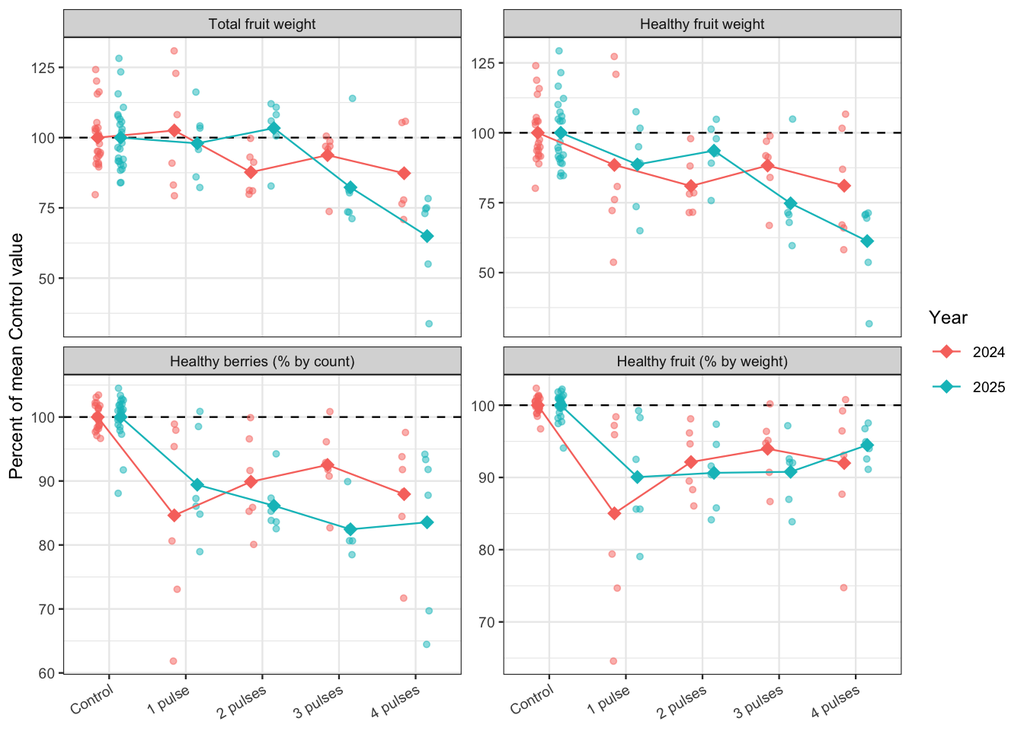

Each yield measure as a percentage of the mean of the Control plots of the same cultivar and year, with both cultivars combined. Small points are individual plots; diamonds joined by lines are group means, coloured by year. The dashed line at 100 marks the Control level. Vertical scales differ between panels.

## 3) How does heat stress affect yield as measured by the total weight of fruit?

First model that we will evaluate will have total weight of the fruit as it’s response variable. We will use heat group, year, cultivar and cultivar-by-year it its fixed part. Additionally we will use a pairID as random intercept for each pair and separate residual variance for control and heated plots.

More information about model evaluation and choice of model can be found in Appendix A.

### 3.1 Final model

The final model for plot $i$ is

$$\log(Y_i) = \mu + \alpha_{g(i)} + \beta_{t(i)} +
(\alpha\beta)_{g(i)\,t(i)} + \gamma_{c(i)} + (\beta\gamma)_{t(i)\,c(i)}
+ b_{k(i)} + \varepsilon_i,$$

where,  
- $Y_i$ is the total fruit weight in grams and $\log$ is the natural logarithm.  
- $\mu$ is the overall intercept,  
- $\alpha_{g}$ the effect of heat group $g$,  
- $\beta_{t}$ the effect of year $t$,  
- $\gamma_{c}$ the effect of cultivar $c$,  
- $(\alpha\beta)_{gt}$ the heat-by-year interaction  
- $(\beta\gamma)_{tc}$ the cultivar-by-year shift.  
- $b_{k}$ is the random intercept of pair $k$, with $b_k \sim N(0, \sigma_b^2)$,  
- $\varepsilon_i$ is the residual error,  
- variance $\sigma^2_{\text{Control}}$ in Control plots  
- $\sigma^2_{\text{Heated}}$ in heated plots.  
- Estimated standard deviations are $\hat\sigma_b = 0.067$, $\hat\sigma_{\text{Control}} = 0.09$ and $\hat\sigma_{\text{Heated}} = 0.164$.

The model was fitted by restricted maximum likelihood in R with nlme.

### 3.2 Coefficients of the final model

Fixed-effect estimates of the final heteroscedastic H2 model.

| Term | Estimate | SE | p_value | Ratio | Lower_95 | Upper_95 |
| --- | --- | --- | --- | --- | --- | --- |
| (Intercept) | 6.987 | 0.031 | < 1e-04 | 1082.535 | 1016.681 | 1152.654 |
| heat_groupD | -0.006 | 0.072 | 0.93396 | 0.994 | 0.859 | 1.150 |
| heat_groupC | -0.140 | 0.072 | 0.05976 | 0.870 | 0.752 | 1.006 |
| heat_groupB | -0.044 | 0.072 | 0.54507 | 0.957 | 0.827 | 1.107 |
| heat_groupA | -0.135 | 0.072 | 0.06883 | 0.874 | 0.755 | 1.011 |
| year2025 | -0.012 | 0.044 | 0.79197 | 0.988 | 0.904 | 1.080 |
| cultivarST | -0.121 | 0.042 | 0.00636 | 0.886 | 0.814 | 0.965 |
| heat_groupD:year2025 | 0.001 | 0.102 | 0.99550 | 1.001 | 0.814 | 1.230 |
| heat_groupC:year2025 | 0.160 | 0.102 | 0.12503 | 1.173 | 0.955 | 1.442 |
| heat_groupB:year2025 | -0.167 | 0.102 | 0.10883 | 0.846 | 0.688 | 1.040 |
| heat_groupA:year2025 | -0.321 | 0.102 | 0.00311 | 0.725 | 0.590 | 0.891 |
| year2025:cultivarST | -0.906 | 0.060 | < 1e-04 | 0.404 | 0.358 | 0.456 |

Control, 2024 and Mullica Queen are the reference levels. A `heat_group` coefficient is the log ratio of total weight in that heat group to Control in 2024 for Mullica Queen. A `:year2025` term is the additional change in 2025, `cultivarST` is the Stevens minus Mullica Queen difference in 2024, and `year2025:cultivarST` is the extra 2025 change for Stevens.

### 3.3 Predicted yields

The figure below shows the fitted mean total fruit weight for each heat group, cultivar and year, with 95% confidence intervals. In 2024 the four heat groups sit close to Control. In 2025 the estimate falls from Control to four pulses. Mullica Queen has the higher baseline, so the same proportional fall is the larger loss in grams.

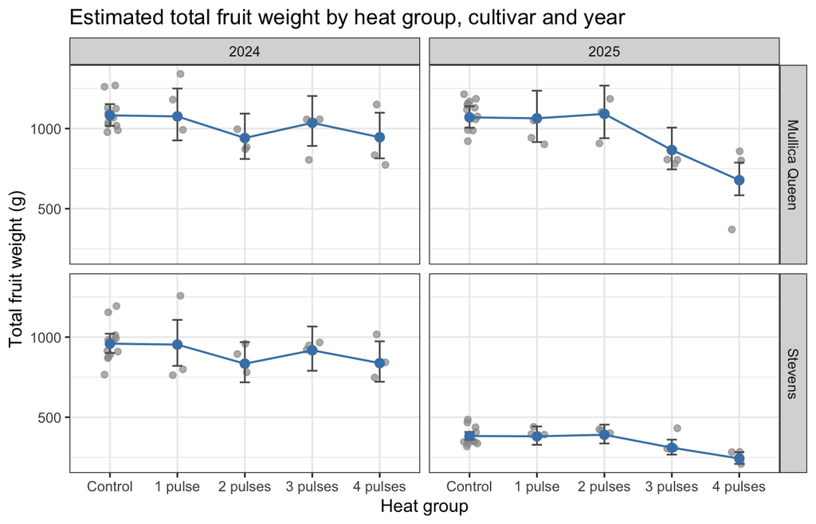

Estimated total fruit weight by heat group, cultivar (rows) and year (columns). Blue points are the means estimated by the final model, joined by lines, with 95% confidence intervals shown as bars; grey points are the individual plots. Control and heated plots are allowed different residual variances, so the intervals of heated plots are wider.

### 3.4 Answer

Heat stress lowers total fruit weight, and the size of the drop depends on the year and on the number of pulses. Averaged over the four heat groups, heated plots produced about 11.5% less fruit than Control. The reduction was about 7.8% in 2024 and about 15.1% in 2025. Within 2025, four pulses gave about 36.6% less fruit than Control and three pulses about 19.1% less. Across the four heat groups the estimate falls by about 9% for each additional pulse, but the slope is weak in 2024 at about −3% per pulse (p = 0.36) and strong in 2025 at about −15% per pulse (p < 0.001). There is no clear heat-by-cultivar interaction (p = 0.28): Mullica Queen and Stevens differ mainly in their baseline, and the Stevens baseline is much lower in 2025. Control and heated plots were also allowed different residual variances, which the likelihood-ratio test supports, so the estimates above come from that model.

## 4) How does heat stress affect yield as measured by the total weight of healthy fruit?

### 4.1 First look

**Comparing each heated plot with its own Control.**  
Figure below shows the ratio of healthy fruit weight between each heated plot and its neighbouring Control plot. In 37 of the 48 pairs (77%), the heated plot produced less healthy fruit than its Control, so heat reduced healthy weight in most pairs. The pattern across heat intensities differed between years. In 2024, the ratios were similar for all four intensities: in most groups, heated plots produced about 15 to 25% less healthy fruit than their Controls, and there was no tendency for more pulses to cause a larger reduction. In 2025, the ratios decreased as the number of heat pulses increased, and heated plots that received three or four pulses produced clearly less healthy fruit than those that received one or two.

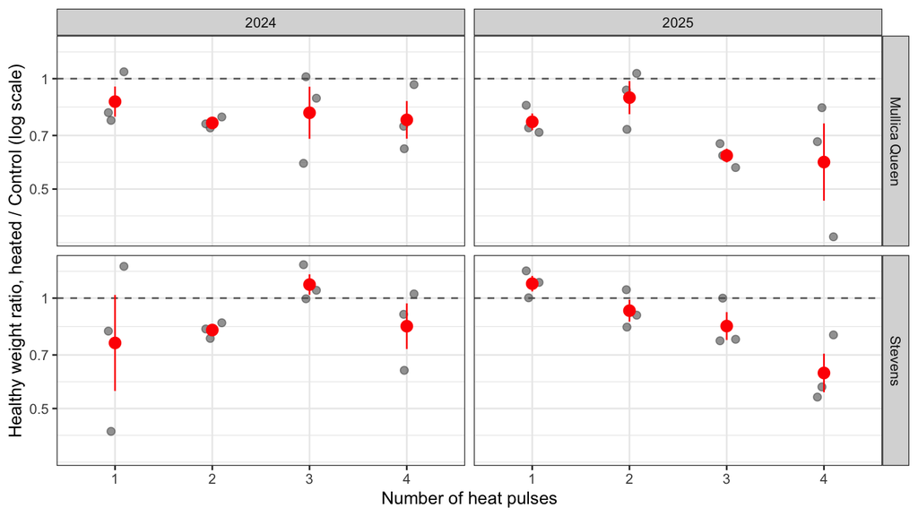

Ratio of healthy fruit weight in each heated (OTC) plot to that in its paired Control plot, by number of heat pulses, cultivar (rows) and year (columns). Grey points are the 48 individual pairs; red points and bars show the mean and plus or minus one standard error of the log ratios. The dashed line marks a ratio of 1 (no difference); points below it are pairs in which the heated plot produced less healthy fruit than its own Control. The vertical axis is on a logarithmic scale.

### 4.2 Methods

We modeled the natural logarithm of healthy fruit weight with a linear mixed model. The fixed effects were heat group (Control or 1, 2, 3 or 4 pulses), year, cultivar, the interaction between heat group and year, and the interaction between year and cultivar. The model also included a random effect for each pair of plots and, because heated plots varied more than Control plots, a separate residual variance for heated and Control plots. It was fitted by restricted maximum likelihood with the nlme package in R. On the log scale, each heat effect is a proportional change, so we report it as the ratio of healthy weight in heated plots to that in Control plots, or as the corresponding percentage reduction. Within each year, we compared the average of the four heat groups with Control, compared each heat group with Control, adjusting for multiple comparisons with Dunnett’s method, and summarised the effect of intensity as the average change per additional pulse among heated plots. We chose this model by comparing it with simpler and more complex alternatives: allowing the heat effect to differ between years improved the fit, whereas allowing it to differ between cultivars did not. Details of the model, its selection and its checks are given in Appendix B.

### 4.3 Results

**Overall effect of heat.**  
Averaged over the four heat groups, both cultivars and both years, heated plots produced 20% less healthy fruit than Control plots (95% CI 14% to 25%, p < 0.001). The average reduction was similar in the two years, 17% in 2024 and 22% in 2025 (Table 3).

Estimated ratio of healthy fruit weight in heated plots to that in Control plots, averaged over the two cultivars; a ratio of 0.80 means 20% less healthy fruit. Results for individual heat groups are adjusted for multiple comparisons (Dunnett’s method). The last row is the change per additional pulse from 1 to 4 pulses.

| Comparison with Control | 2024 ratio (95% CI) | p | 2025 ratio (95% CI) | p |
| --- | --- | --- | --- | --- |
| Average of the four heat groups | 0.83 (0.76–0.92) | < 0.001 | 0.78 (0.71–0.85) | < 0.001 |
| 1 pulse | 0.84 (0.66–1.06) | 0.176 | 0.89 (0.71–1.12) | 0.505 |
| 2 pulses | 0.80 (0.64–1.01) | 0.065 | 0.93 (0.74–1.17) | 0.785 |
| 3 pulses | 0.90 (0.71–1.13) | 0.565 | 0.73 (0.58–0.93) | 0.006 |
| 4 pulses | 0.80 (0.63–1.00) | 0.056 | 0.60 (0.47–0.75) | < 0.001 |
| Per additional pulse | 1.00 (0.92–1.08) | 0.930 | 0.87 (0.80–0.94) | < 0.001 |

**Individual heat groups and dose response.**  
In 2025, the reduction grew with the number of pulses: plots that received three and four pulses produced 27% and 40% less healthy fruit than Control, and each additional pulse reduced healthy weight by about 13% (95% CI 6% to 20%). The estimated reductions for one and two pulses were smaller (11% and 7%), and their confidence intervals range from a reduction of about 29% to an increase of about 17%. In 2024, every heat group was estimated to produce 10% to 20% less healthy fruit than Control, with no trend with the number of pulses. None of these differences was statistically discernible on its own, but their confidence intervals range from reductions of up to about 37% to increases of up to about 13%, so reductions of 20% or more remain plausible at every intensity. The two years therefore differ mainly in how the effect depends on the number of pulses, rather than in its average size.

**Cultivars.**  
There was no evidence that the proportional effect of heat differed between Mullica Queen and Stevens, but because their baselines differ, the same proportional reduction means very different losses in grams (Figure 4). In 2025, for example, four pulses reduced the estimated healthy weight of Mullica Queen from 1037 g to 621 g, but that of Stevens only from 377 g to 225 g.

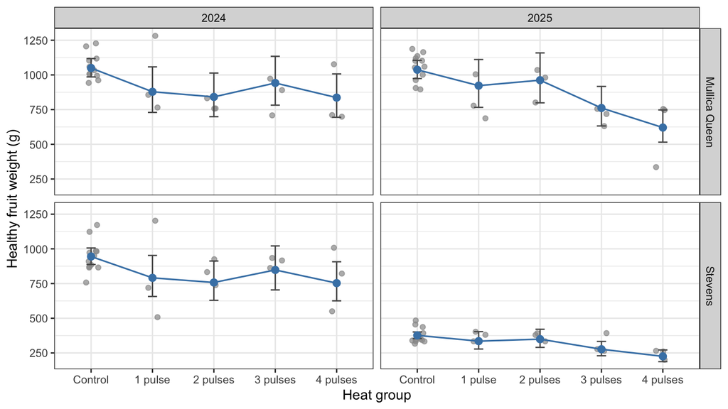

Estimated healthy fruit weight by heat group, cultivar (rows) and year (columns). Blue points are the means estimated by the final model, joined by lines, with 95% confidence intervals shown as bars; grey points are the individual plots. The model assumes that heat reduces healthy weight by the same proportion in both cultivars, so the estimated curves of the two cultivars have the same shape on a proportional scale.

**Sensitivity to extreme plots.**  
Removing the two heated plots with unusually low healthy weight made the estimated effects slightly smaller but did not change these conclusions. The only difference was that two heat groups in 2024 became individually statistically discernible, which confirms that the evidence for individual heat groups in 2024 is borderline (Appendix B.5).

### 4.4 Answer

Heat stress reduced the total weight of healthy fruit by about 20% on average (95% CI 14% to 25%), with a similar average reduction in 2024 and 2025. However, the effect of the number of pulses differed between years: in 2025 the reduction grew by about 13% with each additional pulse and reached about 40% with four pulses, whereas in 2024 the number of pulses made little difference. The proportional effect was similar for both cultivars, so losses in grams were larger for Mullica Queen, which has the higher baseline. Because this reduction is larger than that for total fruit weight (Section 3), heat appears to lower healthy weight partly by increasing the share of rotten fruit.

## 5) How does heat stress affect yield as measured by the percentage of healthy berries by count?

### 5.1 Final model

Final model for to evaluate the effect on percentage of healthy berries by count is as follow :

$$\text{logit}\left(P(Y_{ij} =
\text{healthy})\right) = \beta_0 + \sum_{k=1}^{4} \beta_k \cdot
\text{HeatGroup}_{ijk} + \gamma \cdot \text{Cultivar}_{ij} + \delta
\cdot \text{Year}_{ij} + u_i$$

where:  
* $P(Y_{ij} = \text{healthy})$ represents the probability that a berry in plot $j$ of pair $i$ is healthy.  
* $\beta_0$ is the intercept representing the reference baseline (Mullica Queen, unheated control, 2024).  
* $\text{HeatGroup}_{ijk}$ represents the dummy variables for heat pulse intensity treatments ($D = 1$ pulse, $C = 2$ pulses, $B = 3$ pulses, $A = 4$ pulses relative to plot with no treatment (Control)).  
* $\text{Cultivar}_{ij}$ is the indicator for the Stevens (ST) cultivar relative to Mullica Queen (MQ).  
* $\text{Year}_{ij}$ accounts for the temporal indicator for the 2025 season relative to 2024.  
* $u_i \sim N(0, \sigma^2_u)$ represents the random intercept for the matched plot pair $i$ (`pair_id`).

### 5.2 Results

Fixed Effects, Odds Ratios, and Percentage Changes for Healthy Berry Proportion

| Term | Odds Ratio (95% CI) | Percent Change (95% CI) | Significance |
| --- | --- | --- | --- |
| heat_groupD | 0.275 [0.189, 0.401] | -72.5% [-81.1%, -59.9%] | *** |
| heat_groupC | 0.284 [0.203, 0.397] | -71.6% [-79.7%, -60.3%] | *** |
| heat_groupB | 0.276 [0.197, 0.385] | -72.4% [-80.3%, -61.5%] | *** |
| heat_groupA | 0.238 [0.165, 0.344] | -76.2% [-83.5%, -65.6%] | *** |
| cultivarST | 1.186 [0.924, 1.521] | +18.6% [-7.6%, +52.1%] | Not Significant |
| year2025 | 0.768 [0.599, 0.986] | -23.2% [-40.1%, -1.4%] | * |

The fixed-effects results from the beta-binomial mixed-effects model indicate that under baseline conditions (Mullica Queen cultivar, unheated control plots, 2024), berries had a high baseline probability of remaining healthy, with an intercept odds ratio of 20.16 (p<0.001). All acute heat stress treatments (Groups D through A) dramatically and significantly reduced the odds of fruit health (p<0.001), yielding odds ratios ranging from 0.238 to 0.284, which demonstrates that heat shock severely damages fruit quality regardless of pulse accumulation. When comparing cultivars, the Stevens (ST) variety did not exhibit a statistically significant difference in healthy berry proportion relative to the Mullica Queen (MQ) baseline (OR=1.19, p=0.181).

However, a significant year effect was detected (OR=0.77, p=0.038), reflecting lower baseline fruit health in 2025 compared to 2024 even after controlling for heat treatments and cultivar differences.

### 5.3 Answer

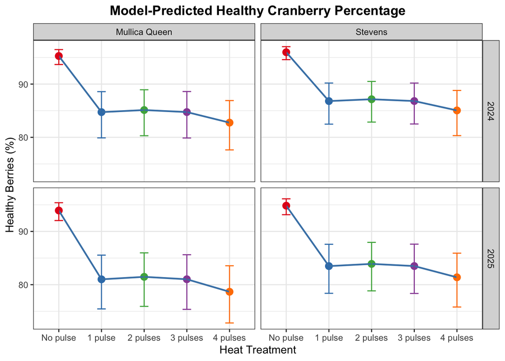

We see that percentage of Healthy berries tend to decrease fast as in between plots of no pulse and heat treated plots. We observe that heat treated plots with 4 pulses have the lowest percentage of healthy berries.

## 6) How does heat stress affect yield as measured by the percentage of healthy fruit by weight?

The second percentage measure uses weight instead of count. For each plot, healthy weight percentage is the weight of healthy fruit divided by total fruit weight, so the value of the variable lies between 0 and 1. Therefore a beta GLMM with a logit link is the natural model for a proportion, with a random intercept for each pair and fixed effects for heat group, cultivar and year was chosen.

### 6.1 Final model

$$\text{logit}(\mu_{ij}) = \beta_0 + \beta_{\text{heat}} \cdot
\text{HeatGroup}_{ij} + \beta_{\text{cultivar}} \cdot
\text{Cultivar}_{ij} + \beta_{\text{year}} \cdot \text{Year}_{ij} + u_i$$
where:
- $\mu_{ij}$ represents the expected proportion of healthy fruit weight in plot $j$ of pair $i$.
- $\text{logit}(\mu_{ij})$ is the logit transformation of the expected healthy fruit weight proportion.
- $\beta_0$ is the intercept representing the reference baseline (Mullica Queen, unheated Control, 2024).
- $\beta_{\text{heat}}$ represents the effect of heat treatment intensity relative to the Control group.
- $\text{Trt}_{ij}$ represents the heat treatment group (D = 1 pulse, C = 2 pulses, B = 3 pulses, A = 4 pulses, relative to Control).
- $\beta_{\text{cult}}$ represents the effect of cultivar.
- $\text{ST}_{ij}$ is the indicator for Stevens (ST) relative to Mullica Queen (MQ).
- $\beta_{\text{year}}$ represents the effect of year.
- $\text{Year2025}_{ij}$ accounts for the 2025 season relative to 2024.
- $u_i \sim N(0,\sigma_u^2)$ represents the random intercept for the matched plot pair $i$ (`pair_id`).

### 6.2 Results

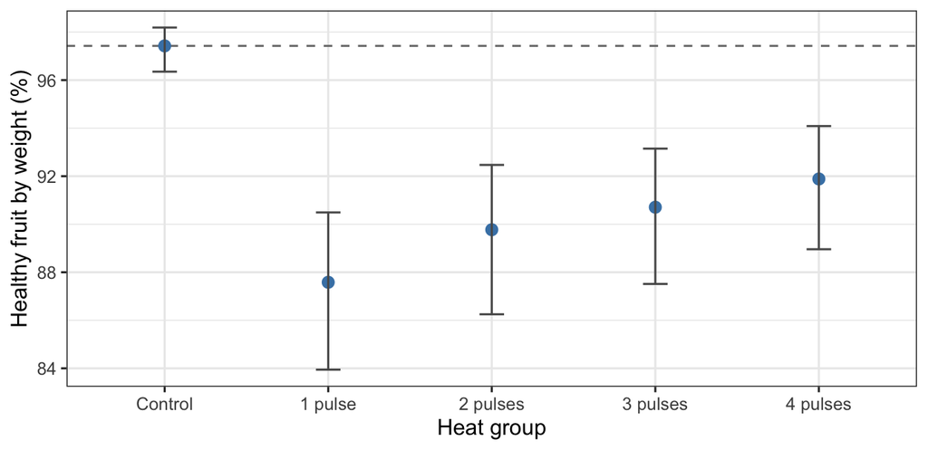

Estimated share of healthy fruit by weight for each heat group, averaged over cultivars and years, with 95% confidence intervals. The dashed line marks the Control estimate.

Control plots keep 97.4% of their harvest weight as healthy fruit. Every heated group is below that, and one pulse is the lowest at 87.6%. The four heat groups average 90.0%, about 7.4 percentage points below Control. The odds that a gram is healthy are 0.30 times the Control odds with four pulses and 0.19 times with one.

### 6.3 Answer

The share of healthy fruit by weight is highest in Control plots, 97.4%, and falls to 87.6% with one pulse. All four heat groups sit between 87.6% and 97.4%, well below Control, and each difference is clear at p < 0.001.

The number of pulses does not order the loss. One and two pulses sit below three and four pulses, so the damage appears once the plots are heated at all rather than growing with each pulse. Year makes no difference for this measure, p = 0.937, while the cultivars differ.

## 7) Conclusion

Mullica Queen and Stevens differ in level more than in sensitivity. Their baselines differ by a wide margin, and the 2025 Stevens baseline is much lower than in 2024, but there is no clear evidence that the proportional effect of heat differs between the cultivars. The same proportional loss therefore costs Mullica Queen more grams.

Three limitations apply. Only the heat treatment was assigned by the experimenters, so only its effects can be read as causal. Each cultivar grew in a single field, so cultivar differences cannot be separated from field differences. With three pairs per heat group in each cultivar and year, comparisons of single heat groups are imprecise, and the models were chosen after examining the data.

## 8) Reference

Bates, D., Mächler, M., Bolker, B., & Walker, S. (2015). Fitting linear mixed-effects models using lme4. *Journal of Statistical Software, 67*(1), 1–48. https://doi.org/10.18637/jss.v067.i01

Brooks, M. E., Kristensen, K., van Benthem, K. J., Magnusson, A., Berg, C. W., Nielsen, A., Skaug, H. J., Mächler, M., & Bolker, B. M. (2017). glmmTMB balances speed and flexibility among packages for zero-inflated generalized linear mixed modeling. *The R Journal, 9*(2), 378–400. https://doi.org/10.32614/RJ-2017-066

Dunnett, C. W. (1955). A multiple comparison procedure for comparing several treatments with a control. *Journal of the American Statistical Association, 50*(272), 1096–1121. https://doi.org/10.1080/01621459.1955.10501294

Ferrari, S. L. P., & Cribari-Neto, F. (2004). Beta regression for modelling rates and proportions. *Journal of Applied Statistics, 31*(7), 799–815. https://doi.org/10.1080/0266476042000214501

Lenth, R. V., & Piaskowski, J. (2026). *emmeans: Estimated marginal means, aka least-squares means* (R package version 2.0.4) [Computer software]. https://doi.org/10.32614/CRAN.package.emmeans

Pinheiro, J. C., & Bates, D. M. (2000). *Mixed-effects models in S and S-PLUS*. Springer. https://doi.org/10.1007/b98882

Pinheiro, J., Bates, D., & R Core Team. (2026). *nlme: Linear and nonlinear mixed effects models* (R package version 3.1-169) [Computer software]. https://doi.org/10.32614/CRAN.package.nlme

R Core Team. (2026). *R: A language and environment for statistical computing* [Computer software]. R Foundation for Statistical Computing. https://www.R-project.org/

Xie, Y. (2026). *knitr: A general-purpose package for dynamic report generation in R* (R package version 1.52) [Computer software]. https://yihui.org/knitr/

## 9) Appendix

### Appendix A: Total weight of fruit (Section 3)

#### A.1 Model specification

The final model for plot $i$ is

$$\log(Y_i) = \mu + \alpha_{g(i)} + \beta_{t(i)} +
(\alpha\beta)_{g(i)\,t(i)} + \gamma_{c(i)} + (\beta\gamma)_{t(i)\,c(i)}
+ b_{k(i)} + \varepsilon_i,$$

where $Y_i$ is the total fruit weight in grams and $\log$ is the natural logarithm. $\mu$ is the overall intercept, $\alpha_{g}$ the effect of heat group $g$, $\beta_{t}$ the effect of year $t$, $\gamma_{c}$ the effect of cultivar $c$, $(\alpha\beta)_{gt}$ the heat-by-year interaction, and $(\beta\gamma)_{tc}$ the cultivar-by-year shift. $b_{k}$ is the random intercept of pair $k$, with $b_k \sim N(0, \sigma_b^2)$, and $\varepsilon_i$ is the residual error, with variance $\sigma^2_{\text{Control}}$ in Control plots and $\sigma^2_{\text{Heated}}$ in heated plots. The estimated standard deviations are $\hat\sigma_b = 0.067$, $\hat\sigma_{\text{Control}} = 0.09$ and $\hat\sigma_{\text{Heated}} = 0.164$. The model was fitted by restricted maximum likelihood in R with nlme. The estimated coefficients are in Section 3.2.

#### A.2 Choice of response scale and model

**Response scale.** Total weight is strictly positive and right-skewed, so the response is logged.

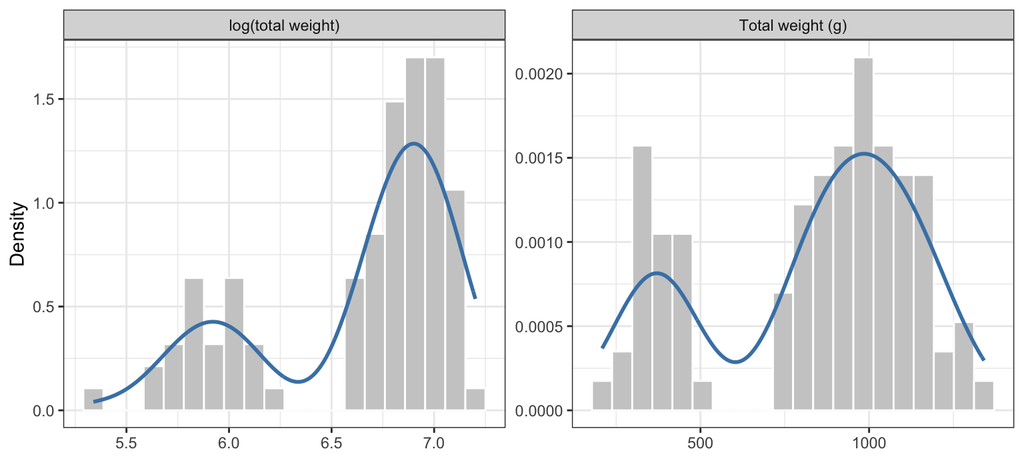

Across the 20 cells defined by cultivar, year and heat group, the Spearman correlation between the group mean and the group standard deviation is 0.49 on the raw scale and -0.15 on the log scale, so the log scale gives the more even spread.

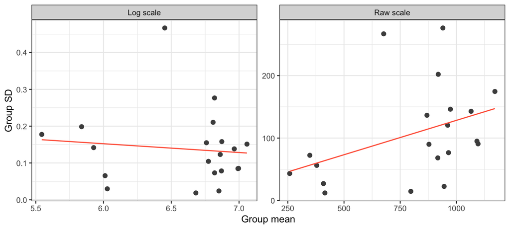

Logging also makes each heat effect a ratio, so a ratio of 0.80 is 20% less fruit.

**Choosing the model.** Five models differ only in how heat enters the fixed part, and all five keep the random intercept for pair and the cultivar-by-year shift. H0 has one heat effect. H1 lets it differ by cultivar, H2 by year, and H3 includes both interactions. H4 replaces the five-level heat group by treatment by intensity, which splits the Control plots by the intensity of their paired heated plot instead of pooling them, so it tests whether pooling is justified.

The profiles below motivate the heat-by-year term: in 2024 the heat groups are close to Control, whereas in 2025 the mean falls with the number of pulses, and Stevens is much lower in 2025 than in 2024.

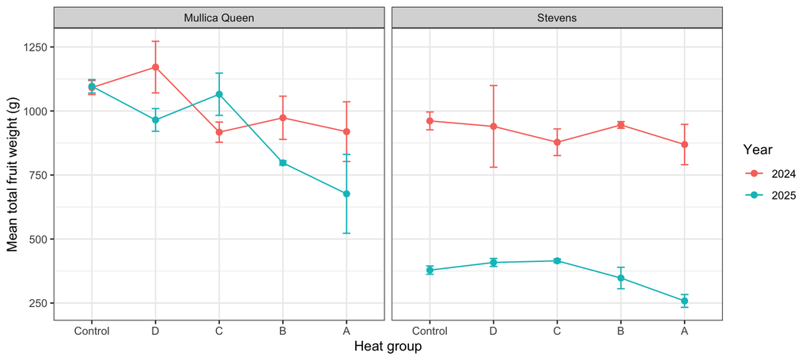

Mean total fruit weight by heat group and year, separately for each cultivar. In 2024 the four heat groups are close to Control; in 2025 the mean falls with the number of pulses, and Stevens is much lower than in 2024.

The candidate fixed-effect structures are:

AIC comparison for total weight (ML fits).

| Model | df | AIC | dAIC |
| --- | --- | --- | --- |
| H0 | 10 | -71.59 | 13.01 |
| H1 | 14 | -68.64 | 15.96 |
| H2 | 14 | -84.60 | 0.00 |
| H3 | 18 | -83.69 | 0.91 |
| H4 | 13 | -66.65 | 17.95 |

```
## $cult
## Data: data
## Models:
## tw_h0: log(total_weight) ~ heat_group + cultivar + year + year:cultivar + (1 | pair_id)
## tw_h1: log(total_weight) ~ heat_group * cultivar + year + year:cultivar + (1 | pair_id)
##       npar     AIC     BIC logLik -2*log(L)  Chisq Df Pr(>Chisq)
## tw_h0   10 -71.594 -45.951 45.797   -91.594
## tw_h1   14 -68.637 -32.736 48.318   -96.637 5.0426  4      0.283
##
## $year
## Data: data
## Models:
## tw_h0: log(total_weight) ~ heat_group + cultivar + year + year:cultivar + (1 | pair_id)
## tw_h2: log(total_weight) ~ heat_group * year + cultivar + year:cultivar + (1 | pair_id)
##       npar     AIC     BIC logLik -2*log(L)  Chisq Df Pr(>Chisq)
## tw_h0   10 -71.594 -45.951 45.797   -91.594
## tw_h2   14 -84.599 -48.698 56.300  -112.599 21.005  4  0.0003159 ***
## ---
## Signif. codes:  0 '***' 0.001 '**' 0.01 '*' 0.05 '.' 0.1 ' ' 1
##
## $both
## Data: data
## Models:
## tw_h0: log(total_weight) ~ heat_group + cultivar + year + year:cultivar + (1 | pair_id)
## tw_h3: log(total_weight) ~ heat_group * (cultivar + year) + year:cultivar + (1 | pair_id)
##       npar     AIC     BIC logLik -2*log(L)  Chisq Df Pr(>Chisq)
## tw_h0   10 -71.594 -45.951 45.797   -91.594
## tw_h3   18 -83.688 -37.530 59.844  -119.688 28.094  8  0.0004567 ***
## ---
## Signif. codes:  0 '***' 0.001 '**' 0.01 '*' 0.05 '.' 0.1 ' ' 1
##
## $year_after_cult
## Data: data
## Models:
## tw_h1: log(total_weight) ~ heat_group * cultivar + year + year:cultivar + (1 | pair_id)
## tw_h3: log(total_weight) ~ heat_group * (cultivar + year) + year:cultivar + (1 | pair_id)
##       npar     AIC     BIC logLik -2*log(L)  Chisq Df Pr(>Chisq)
## tw_h1   14 -68.637 -32.736 48.318   -96.637
## tw_h3   18 -83.688 -37.530 59.844  -119.688 23.052  4  0.0001237 ***
## ---
## Signif. codes:  0 '***' 0.001 '**' 0.01 '*' 0.05 '.' 0.1 ' ' 1
##
## $cult_after_year
## Data: data
## Models:
## tw_h2: log(total_weight) ~ heat_group * year + cultivar + year:cultivar + (1 | pair_id)
## tw_h3: log(total_weight) ~ heat_group * (cultivar + year) + year:cultivar + (1 | pair_id)
##       npar     AIC     BIC logLik -2*log(L)  Chisq Df Pr(>Chisq)
## tw_h2   14 -84.599 -48.698 56.300   -112.60
## tw_h3   18 -83.688 -37.530 59.844   -119.69 7.0888  4     0.1313
```

H2 has the smallest AIC, so we take H2. The likelihood-ratio tests agree: heat by year improves the fit at p = <0.001, heat by cultivar does not at p = 0.283, and adding heat by cultivar after heat by year leaves the fit unchanged at p = 0.131. H4 has a larger AIC than H2, so the Control plots can be pooled into one Control group.

#### A.3 Residual variance and model checks

The selected model assumes one residual variance. Control and heated plots may differ in spread, so the same fixed and random effects were refitted in nlme with a separate residual variance for each group:

**Residual spread.** With one residual variance the residuals of heated plots are more spread out than those of Control plots. Ignoring this would make comparisons of heated plots look more precise than they are. The likelihood-ratio test of the extra variance gives p = 0.00464, and the estimated residual standard deviation of heated plots is 1.8 times that of Control plots.

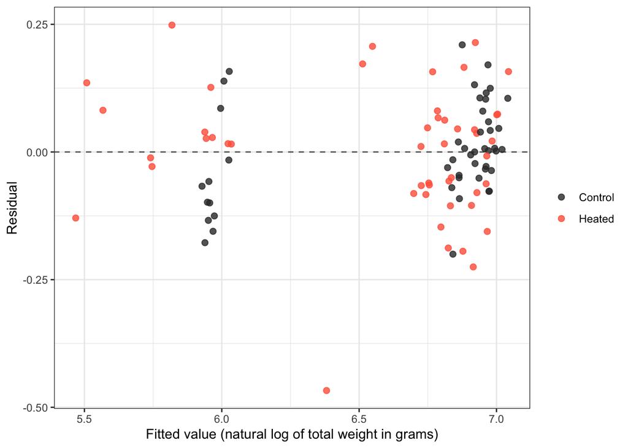

Residuals against fitted values from the selected model fitted with a single residual variance for all plots. Each point is one plot; black points are Control plots and red points are heated plots. The dashed line marks zero. The residuals of heated plots are clearly more spread out than those of Control plots.

After the refit the Pearson residuals and the estimated pair effects are close to normal.

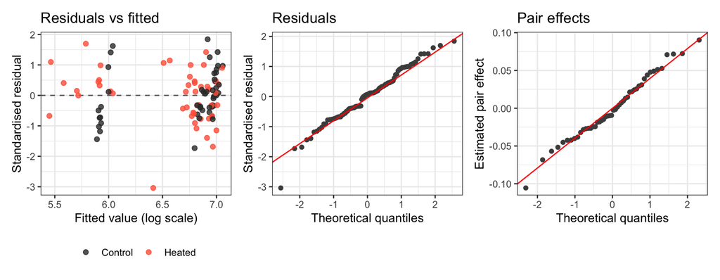

Diagnostic plots for the final model, which allows separate residual variances for heated and Control plots. Left: standardised (Pearson) residuals against fitted values; black points are Control plots and red points are heated plots, and the dashed line marks zero. Middle: normal quantile plot of the standardised residuals. Right: normal quantile plot of the estimated pair effects. Points close to the red lines indicate approximately normal distributions.

#### A.4 Sensitivity analysis

We removed the 3 pairs that hold the three largest standardised residuals, 6 plots in all, and refitted the final model. The average reduction over the four heat groups is 7% in 2024 and 13% in 2025, against 8% and 15% for the full data, so the conclusions do not depend on these plots.

### Appendix B: Total weight of healthy fruit (Section 4)

### B.1 Model specification

The final model for plot $i$ is

$$\log(Y_i) = \mu + \alpha_{g(i)} + \beta_{t(i)} +
(\alpha\beta)_{g(i)\,t(i)} + \gamma_{c(i)} + (\beta\gamma)_{t(i)\,c(i)}
+ b_{k(i)} + \varepsilon_i,$$

where $Y_i$ is the healthy fruit weight in grams, $\log$ is the natural logarithm, $\mu$ is the overall intercept, $\alpha_{g}$ is the effect of heat group $g$ (Control or 1, 2, 3 or 4 pulses), $\beta_{t}$ is the effect of year $t$, $\gamma_{c}$ is the effect of cultivar $c$, $(\alpha\beta)_{gt}$ allows the heat effect to differ between years, and $(\beta\gamma)_{tc}$ allows the cultivar baseline to differ between years. The term $b_{k}$ is the random effect of pair $k$, with $b_k \sim N(0, \sigma_b^2)$, and $\varepsilon_i$ is the residual error, with $\varepsilon_i \sim N(0, \sigma^2_{\text{Control}})$ for Control plots and $\varepsilon_i \sim N(0, \sigma^2_{\text{Heated}})$ for heated plots. The estimated standard deviations are $\hat\sigma_b = 0.062$, $\hat\sigma_{\text{Control}} = 0.093$ and $\hat\sigma_{\text{Heated}} = 0.212$. The model was fitted by restricted maximum likelihood with the nlme package in R. The estimated coefficients are listed in Table 9 (Appendix B.4).

### B.2 Choice of response scale and model

**Response scale.** We modelled the natural logarithm of healthy weight. On the original scale, groups with a higher mean healthy weight also varied more (Spearman correlation between group mean and group standard deviation 0.44 across the 20 combinations of cultivar, year and heat group), which violates the model’s assumption of equal variance; on the log scale this association was much weaker (-0.22).

### B.3 Residual variance and model checks

**Unequal variances in heated and Control plots.** When the selected model was fitted with the same residual variance for all plots, the residuals of heated plots were clearly more spread out than those of Control plots (Figure 12). Ignoring this would understate the uncertainty of comparisons involving heated plots, so we refitted the model with separate residual variances for heated and Control plots, which fitted much better (likelihood-ratio test, p < 0.001). The estimated residual standard deviation of heated plots was about 2.3 times that of Control plots. With this change, the residuals had a similar spread in both groups and both the residuals and the estimated pair effects were close to normally distributed (Figure 13), apart from two heated plots with unusually low healthy weight, which we examine in Appendix B.5.

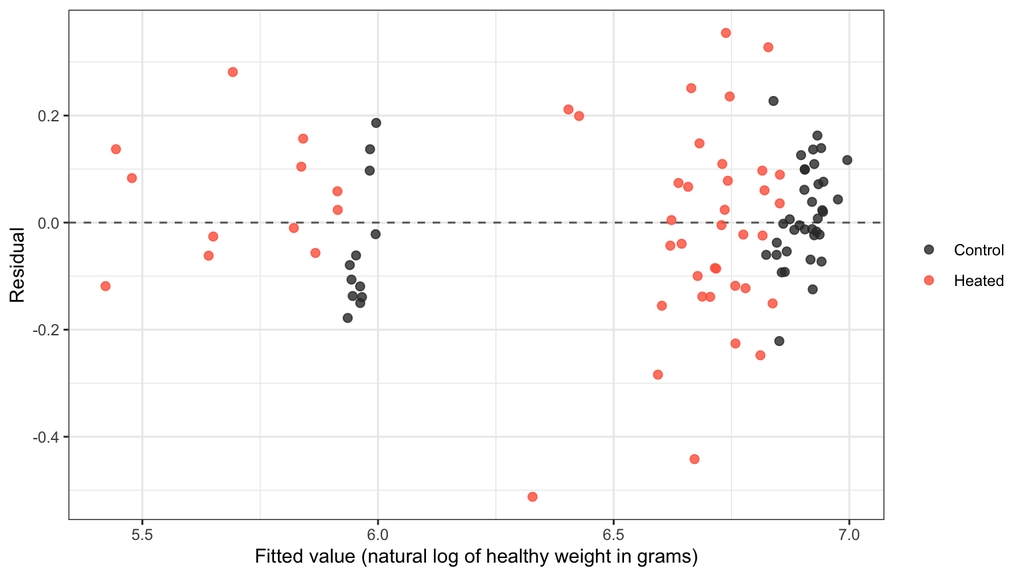

Residuals against fitted values from the selected model fitted with a single residual variance for all plots. Each point is one plot. Black points are Control plots and red points are heated plots. The dashed line marks zero. The residuals of heated plots are clearly more spread out than those of Control plots.

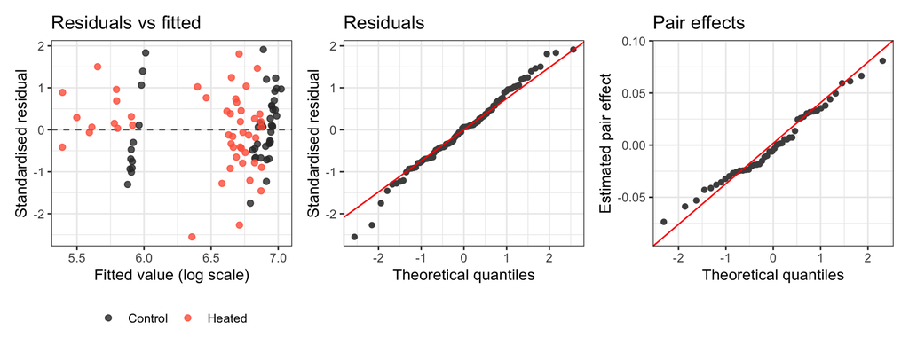

Diagnostic plots for the final model, which allows separate residual variances for heated and Control plots. Left: standardised (Pearson) residuals against fitted values. Black points are Control plots and red points are heated plots, and the dashed line marks zero. Middle: normal quantile plot of the standardised residuals. Right: normal quantile plot of the estimated pair effects. Points close to the red lines indicate approximately normal distributions.

### B.4 Coefficients

Estimated fixed effects of the final model. Estimates are on the natural log scale. Ratio is the exponential of the estimate, i.e. the multiplicative change in healthy weight. The reference levels are Control, 2024 and Mullica Queen. For the intercept, the exponential is the estimated healthy weight in grams of Control plots of Mullica Queen in 2024. The heat group terms compare each heat group with Control in 2024, the terms marked × 2025 give the additional multiplicative change in 2025.

| Term | Estimate (log scale) | Standard error | Ratio | 95% CI for ratio | p-value |
| --- | --- | --- | --- | --- | --- |
| Intercept (Control, 2024, Mullica Queen) | 6.956 | 0.031 | 1049.56 | 985.47 to 1117.83 | < 0.001 |
| 1 pulse | -0.178 | 0.091 | 0.84 | 0.70 to 1.01 | 0.057 |
| 2 pulses | -0.221 | 0.091 | 0.80 | 0.67 to 0.96 | 0.019 |
| 3 pulses | -0.108 | 0.091 | 0.90 | 0.75 to 1.08 | 0.239 |
| 4 pulses | -0.227 | 0.091 | 0.80 | 0.66 to 0.96 | 0.016 |
| Year 2025 | -0.012 | 0.044 | 0.99 | 0.90 to 1.08 | 0.791 |
| Stevens | -0.105 | 0.043 | 0.90 | 0.83 to 0.98 | 0.018 |
| 1 pulse × 2025 | 0.061 | 0.128 | 1.06 | 0.82 to 1.38 | 0.638 |
| 2 pulses × 2025 | 0.146 | 0.128 | 1.16 | 0.89 to 1.50 | 0.262 |
| 3 pulses × 2025 | -0.201 | 0.128 | 0.82 | 0.63 to 1.06 | 0.125 |
| 4 pulses × 2025 | -0.287 | 0.128 | 0.75 | 0.58 to 0.97 | 0.031 |
| 2025 × Stevens | -0.908 | 0.061 | 0.40 | 0.36 to 0.46 | < 0.001 |

### B.5 Sensitivity analysis

To check whether our conclusions depend on the two heated plots with unusually low healthy weight, we removed the 2 pairs containing them (4 plots, 4.2% of the data) and refitted the final model. The estimated effects became slightly smaller, but all main conclusions were unchanged: the average reduction was 14% in 2024 and 20% in 2025, and the reduction per additional pulse in 2025 was 10%. The only change was that two heat groups in 2024 became individually statistically discernible, which confirms that the evidence for individual heat groups in 2024 is borderline.

### Appendix C: Healthy count: model building (Section 5)

#### C.1 Model Specification

Model Comparison for Healthy Berry Proportion

| Outcome | Model | df | AIC | BIC | LRT_p |
| --- | --- | --- | --- | --- | --- |
| Healthy berry proportion | Additive | 9 | 858.117 | 881.196 | NA |
| Healthy berry proportion | Two-way interactions | 18 | 866.476 | 912.635 | 0.380 |
| Healthy berry proportion | Three-way interactions | 22 | 866.530 | 922.946 | 0.094 |

From the anova table from above, we can observe that the additive model yeilds the least AIC value whilst still controlling for the complexity. Therefore, m_add_prop was chosen as the model to explain the percentage of healthy fruit by count.

#### C.2 Results

Fixed Effects, Odds Ratios, and Percentage Changes for Healthy Berry Proportion

| Term | Odds Ratio (95% CI) | Percent Change (95% CI) | Significance |
| --- | --- | --- | --- |
| heat_groupD | 0.275 [0.189, 0.401] | -72.5% [-81.1%, -59.9%] | *** |
| heat_groupC | 0.284 [0.203, 0.397] | -71.6% [-79.7%, -60.3%] | *** |
| heat_groupB | 0.276 [0.197, 0.385] | -72.4% [-80.3%, -61.5%] | *** |
| heat_groupA | 0.238 [0.165, 0.344] | -76.2% [-83.5%, -65.6%] | *** |
| cultivarST | 1.186 [0.924, 1.521] | +18.6% [-7.6%, +52.1%] | Not Significant |
| year2025 | 0.768 [0.599, 0.986] | -23.2% [-40.1%, -1.4%] | * |

The fixed-effects results from the beta-binomial mixed-effects model indicate that under baseline conditions (Mullica Queen cultivar, unheated control plots, 2024), berries had a high baseline probability of remaining healthy, with an intercept odds ratio of 20.16 (p<0.001). All acute heat stress treatments (Groups D through A) dramatically and significantly reduced the odds of fruit health (p<0.001), yielding odds ratios ranging from 0.238 to 0.284, which demonstrates that heat shock severely damages fruit quality regardless of pulse accumulation. When comparing cultivars, the Stevens (ST) variety did not exhibit a statistically significant difference in healthy berry proportion relative to the Mullica Queen (MQ) baseline (OR=1.19, p=0.181).

However, a significant year effect was detected (OR=0.77, p=0.038), reflecting lower baseline fruit health in 2025 compared to 2024 even after controlling for heat treatments and cultivar differences.

#### C.3 Answer

Predicted Healthy Berry Proportions

| heat_group | cultivar | year | prob | SE | df | asymp.LCL | asymp.UCL |
| --- | --- | --- | --- | --- | --- | --- | --- |
| Control | MQ | 2024 | 0.953 | 0.007 | Inf | 0.937 | 0.965 |
| D | MQ | 2024 | 0.847 | 0.022 | Inf | 0.799 | 0.886 |
| C | MQ | 2024 | 0.851 | 0.022 | Inf | 0.803 | 0.889 |
| B | MQ | 2024 | 0.847 | 0.022 | Inf | 0.799 | 0.886 |
| A | MQ | 2024 | 0.828 | 0.024 | Inf | 0.776 | 0.869 |
| Control | ST | 2024 | 0.960 | 0.006 | Inf | 0.946 | 0.970 |
| D | ST | 2024 | 0.868 | 0.020 | Inf | 0.825 | 0.902 |
| C | ST | 2024 | 0.872 | 0.019 | Inf | 0.829 | 0.905 |
| B | ST | 2024 | 0.868 | 0.020 | Inf | 0.825 | 0.902 |
| A | ST | 2024 | 0.851 | 0.022 | Inf | 0.803 | 0.888 |
| Control | MQ | 2025 | 0.939 | 0.008 | Inf | 0.920 | 0.954 |
| D | MQ | 2025 | 0.810 | 0.026 | Inf | 0.754 | 0.855 |
| C | MQ | 2025 | 0.815 | 0.026 | Inf | 0.759 | 0.860 |
| B | MQ | 2025 | 0.810 | 0.026 | Inf | 0.754 | 0.856 |
| A | MQ | 2025 | 0.787 | 0.027 | Inf | 0.728 | 0.836 |
| Control | ST | 2025 | 0.948 | 0.008 | Inf | 0.931 | 0.961 |
| D | ST | 2025 | 0.835 | 0.023 | Inf | 0.784 | 0.876 |
| C | ST | 2025 | 0.839 | 0.023 | Inf | 0.788 | 0.879 |
| B | ST | 2025 | 0.835 | 0.024 | Inf | 0.784 | 0.876 |
| A | ST | 2025 | 0.814 | 0.026 | Inf | 0.758 | 0.859 |

Healthy Berry Proportion Comparisons Against Control

| contrast | cultivar | year | odds.ratio | SE | df | asymp.LCL | asymp.UCL | null | z.ratio | p.value |
| --- | --- | --- | --- | --- | --- | --- | --- | --- | --- | --- |
| D / Control | MQ | 2024 | 0.275 | 0.053 | Inf | 0.172 | 0.441 | 1 | -6.720 | 0 |
| C / Control | MQ | 2024 | 0.284 | 0.049 | Inf | 0.187 | 0.432 | 1 | -7.369 | 0 |
| B / Control | MQ | 2024 | 0.276 | 0.047 | Inf | 0.182 | 0.418 | 1 | -7.580 | 0 |
| A / Control | MQ | 2024 | 0.238 | 0.045 | Inf | 0.150 | 0.377 | 1 | -7.658 | 0 |
| D / Control | ST | 2024 | 0.275 | 0.053 | Inf | 0.172 | 0.441 | 1 | -6.720 | 0 |
| C / Control | ST | 2024 | 0.284 | 0.049 | Inf | 0.187 | 0.432 | 1 | -7.369 | 0 |
| B / Control | ST | 2024 | 0.276 | 0.047 | Inf | 0.182 | 0.418 | 1 | -7.580 | 0 |
| A / Control | ST | 2024 | 0.238 | 0.045 | Inf | 0.150 | 0.377 | 1 | -7.658 | 0 |
| D / Control | MQ | 2025 | 0.275 | 0.053 | Inf | 0.172 | 0.441 | 1 | -6.720 | 0 |
| C / Control | MQ | 2025 | 0.284 | 0.049 | Inf | 0.187 | 0.432 | 1 | -7.369 | 0 |
| B / Control | MQ | 2025 | 0.276 | 0.047 | Inf | 0.182 | 0.418 | 1 | -7.580 | 0 |
| A / Control | MQ | 2025 | 0.238 | 0.045 | Inf | 0.150 | 0.377 | 1 | -7.658 | 0 |
| D / Control | ST | 2025 | 0.275 | 0.053 | Inf | 0.172 | 0.441 | 1 | -6.720 | 0 |
| C / Control | ST | 2025 | 0.284 | 0.049 | Inf | 0.187 | 0.432 | 1 | -7.369 | 0 |
| B / Control | ST | 2025 | 0.276 | 0.047 | Inf | 0.182 | 0.418 | 1 | -7.580 | 0 |
| A / Control | ST | 2025 | 0.238 | 0.045 | Inf | 0.150 | 0.377 | 1 | -7.658 | 0 |

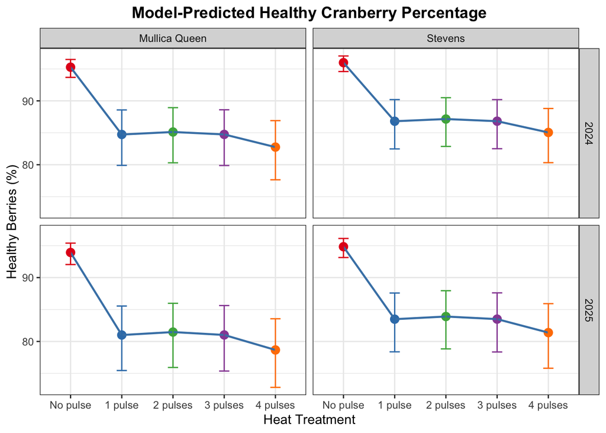

### Appendix D: Share of healthy fruit by weight: model building (Section 6)

#### D.1 Model Selection

| Model | df | AIC | BIC | LRT_p |
| --- | --- | --- | --- | --- |
| Additive (M_add) | 9 | -392.855 | -369.776 | NA |
| 2-Way Interactions (M_2way) | 18 | -380.465 | -334.307 | 0.778 |
| 3-Way Interactions (M_3way) | 22 | -380.284 | -323.869 | 0.098 |

Here, the AIC value that is the least is yielded by the additive model. Therefore, the additive model has been chosen as the ideal model to proceed with evaluating the heat effect on the percentage of healthy fruit weight.

| Heat_Group | Estimate | IRR | Percent_Change | Significance |
| --- | --- | --- | --- | --- |
| D | -1.679 | 0.187 | -81.349 | Sufficient statistical evidence to conclude that an association or difference exists. |
| C | -1.461 | 0.232 | -76.793 | Sufficient statistical evidence to conclude that an association or difference exists. |
| B | -1.354 | 0.258 | -74.188 | Sufficient statistical evidence to conclude that an association or difference exists. |
| A | -1.206 | 0.299 | -70.063 | Sufficient statistical evidence to conclude that an association or difference exists. |

We can observe there the effect of heat in the yield of percentage of healthy fruit weight is in the negative direction. This means that the the heat pulses reduces the number yeild of proportion of healthy fruit weights.

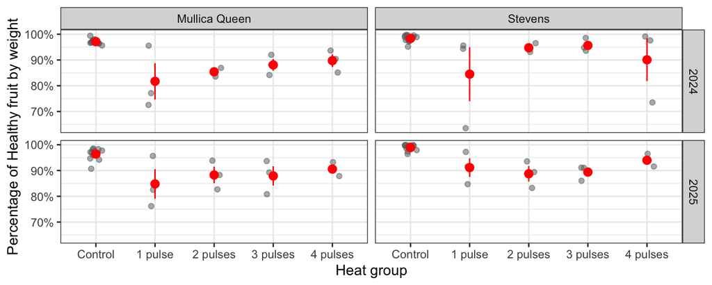

Percentage of healthy fruit by weight for each plot, by heat group, with the mean and one standard error in red. The share is bounded by 0 and 1, which is why a beta model is used.

The share is a proportion bounded by 0 and 1, and its variance depends on its mean. None of the 96 plots sits exactly at 0 or 1; the observed shares run from about 64% to nearly 100%. A beta GLMM on the logit scale is used, with a random intercept for pair.

The beta-binomial model on the counts of healthy and rotten berries is an alternative way to describe the same composition, but it models a share of berries by number, not a share of weight, so its likelihood is not comparable with the beta model. The beta model on the proportion is used for the results in Section 6.

Year contributes little to the share by weight. Dropping it changes the fit by p = 0.937, so the year term is kept only so that this model has the same fixed-effect structure as the other yield models and the measures stay comparable.

```
##  heat_group response     SE  df asymp.LCL asymp.UCL
##  Control       0.974 0.0046 Inf     0.964     0.982
##  D             0.876 0.0166 Inf     0.839     0.905
##  C             0.898 0.0157 Inf     0.863     0.925
##  B             0.907 0.0142 Inf     0.875     0.931
##  A             0.919 0.0129 Inf     0.890     0.941
##
## Results are averaged over the levels of: cultivar, year
## Confidence level used: 0.95
## Intervals are back-transformed from the logit scale
```

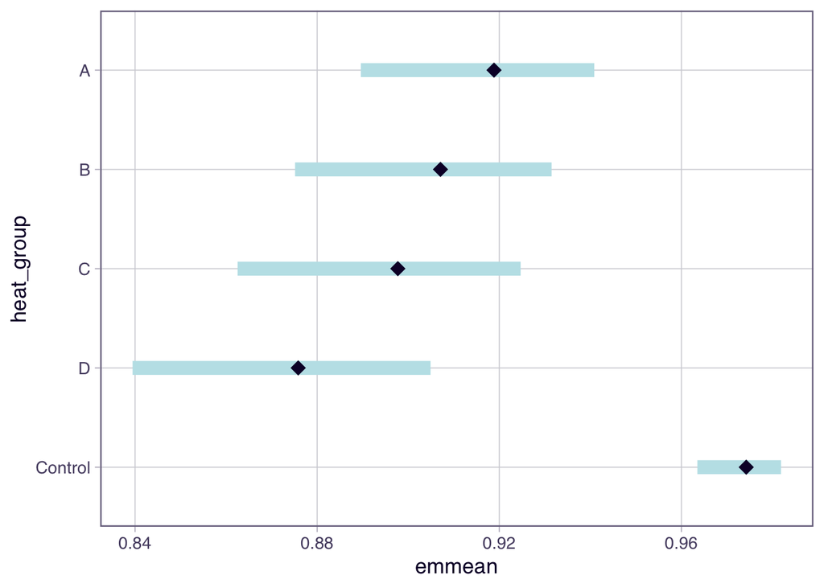

|  | Term | Odds_Ratio | CI_Lower | CI_Upper | p_value |
| --- | --- | --- | --- | --- | --- |
| (Intercept) | (Intercept) | 27.7331821 | 18.4792710 | 41.6211976 | 6.600558e-58 |
| heat_groupD | heat_groupD | 0.1865089 | 0.1143660 | 0.3041600 | 1.698841e-11 |
| heat_groupC | heat_groupC | 0.2320683 | 0.1553789 | 0.3466089 | 9.555779e-13 |
| heat_groupB | heat_groupB | 0.2581160 | 0.1695493 | 0.3929468 | 2.679090e-10 |
| heat_groupA | heat_groupA | 0.2993679 | 0.1827910 | 0.4902930 | 1.653208e-06 |
| cultivarST | cultivarST | 1.8390479 | 1.3898800 | 2.4333736 | 2.005567e-05 |
| factor(year)2025 | factor(year)2025 | 1.0111895 | 0.7668041 | 1.3334620 | 9.371646e-01 |

```
##  heat_group response     SE  df asymp.LCL asymp.UCL
##  Control       0.974 0.0046 Inf     0.964     0.982
##  D             0.876 0.0166 Inf     0.839     0.905
##  C             0.898 0.0157 Inf     0.863     0.925
##  B             0.907 0.0142 Inf     0.875     0.931
##  A             0.919 0.0129 Inf     0.890     0.941
##
## Results are averaged over the levels of: cultivar, year
## Confidence level used: 0.95
## Intervals are back-transformed from the logit scale
```

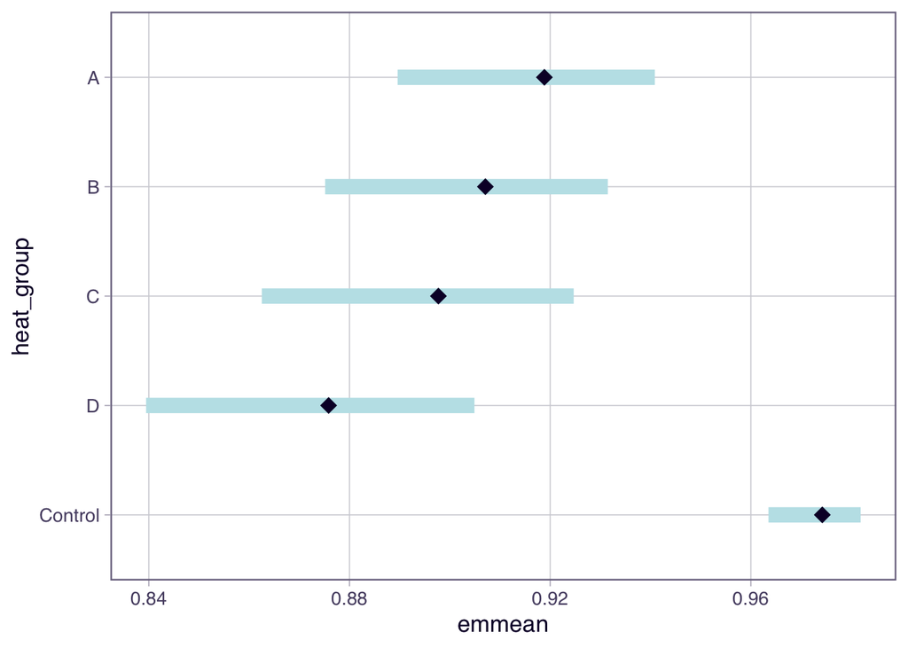

```
##  contrast    odds.ratio    SE  df null z.ratio p.value
##  Control / D      5.362 1.340 Inf    1   6.730 <0.0001
##  Control / C      4.309 0.882 Inf    1   7.137 <0.0001
##  Control / B      3.874 0.831 Inf    1   6.316 <0.0001
##  Control / A      3.340 0.841 Inf    1   4.792 <0.0001
##  D / C            0.804 0.191 Inf    1  -0.920  0.8893
##  D / B            0.723 0.168 Inf    1  -1.394  0.6317
##  D / A            0.623 0.141 Inf    1  -2.086  0.2260
##  C / B            0.899 0.203 Inf    1  -0.471  0.9899
##  C / A            0.775 0.191 Inf    1  -1.034  0.8399
##  B / A            0.862 0.210 Inf    1  -0.609  0.9737
##
## Results are averaged over the levels of: cultivar, year
## P value adjustment: tukey method for comparing a family of 5 estimates
## Tests are performed on the log odds ratio scale
```